# Student Performance Analysis and Prediction

Kumar Kalyan Budiredla and Prabhu Kurra

# R Setup

```r
knitr::opts_chunk$set(echo = TRUE,message = FALSE)
```

# Problem_Statement

Developing a predictive model for academic performance using linear regression

# Dataset Information

This dataset is collected from the kaggle and it contains Information related to student performance and habits

```r
#importing the package
suppressPackageStartupMessages(library(tidyverse))
student_performance_data <- read_csv("Student_Performance.csv",show_col_types = FALSE)
```

# Data Understanding and EDA

Renaming columns:

I want to rename the columns before EDA as spaces between column names makes it difficult while coding.Additionally, one can rename the columns to descriptive names as they provide clear understanding of variables and makes it easier to explore the data.

```r
#first let us check the column names
names(student_performance_data)
```

```
## [1] "Hours Studied"                    "Previous Scores"
## [3] "Extracurricular Activities"       "Sleep Hours"
## [5] "Sample Question Papers Practiced" "Performance Index"
```

If you observe in the above output the column names contain spaces , let’s remove that spaces and rename some column names in more descriptive way

```r
student_performance_data <- student_performance_data %>%
  rename_all(~sub("\\s+", "_", .))
names(student_performance_data)[c(3,5)] <- c("Participation_in_Extracurricular_Activities","No_Of_Sample_Question_Papers_Practiced")
names(student_performance_data)
```

```
## [1] "Hours_Studied"
## [2] "Previous_Scores"
## [3] "Participation_in_Extracurricular_Activities"
## [4] "Sleep_Hours"
## [5] "No_Of_Sample_Question_Papers_Practiced"
## [6] "Performance_Index"
```

Data Dictionary

```r
#viewing first few rows
head(student_performance_data)
```

```
## # A tibble: 6 × 6
##   Hours_Studied Previous_Scores Participation_in_Extracurricular_A…¹ Sleep_Hours
##           <dbl>           <dbl> <chr>                                      <dbl>
## 1             7              99 Yes                                            9
## 2             4              82 No                                             4
## 3             8              51 Yes                                            7
## 4             5              52 Yes                                            5
## 5             7              75 No                                             8
## 6             3              78 No                                             9
## # ℹ abbreviated name: ¹Participation_in_Extracurricular_Activities
## # ℹ 2 more variables: No_Of_Sample_Question_Papers_Practiced <dbl>,
## #   Performance_Index <dbl>
```

1. Hours_Studied - The amount of time the student studied
2. Previous_Scores - Scores from the previous assessments
3. Participation_in_Extracurricular_Activities - Participation of students in extra curricular activities
4. Sleep_Hours - The number of hours devoted to sleep
5. No_Of_Sample_Question_Papers_Practiced - Number of sample question papers practiced
6. Performance_Index - The ultimate measure of student’s academic performance, It ranges from 10 to 100. The higher the performance, the better the performance

# Exploratory Data Analysis

```r
str(student_performance_data)
```

```
## spc_tbl_ [10,000 × 6] (S3: spec_tbl_df/tbl_df/tbl/data.frame)
##  $ Hours_Studied                              : num [1:10000] 7 4 8 5 7 3 7 8 5 4 ...
##  $ Previous_Scores                            : num [1:10000] 99 82 51 52 75 78 73 45 77 89 ...
##  $ Participation_in_Extracurricular_Activities: chr [1:10000] "Yes" "No" "Yes" "Yes" ...
##  $ Sleep_Hours                                : num [1:10000] 9 4 7 5 8 9 5 4 8 4 ...
##  $ No_Of_Sample_Question_Papers_Practiced     : num [1:10000] 1 2 2 2 5 6 6 6 2 0 ...
##  $ Performance_Index                          : num [1:10000] 91 65 45 36 66 61 63 42 61 69 ...
##  - attr(*, "spec")=
##   .. cols(
##   ..   `Hours Studied` = col_double(),
##   ..   `Previous Scores` = col_double(),
##   ..   `Extracurricular Activities` = col_character(),
##   ..   `Sleep Hours` = col_double(),
##   ..   `Sample Question Papers Practiced` = col_double(),
##   ..   `Performance Index` = col_double()
##   .. )
##  - attr(*, "problems")=<externalptr>
```

```r
summary(student_performance_data)
```

```
##  Hours_Studied   Previous_Scores Participation_in_Extracurricular_Activities
##  Min.   :1.000   Min.   :40.00   Length:10000
##  1st Qu.:3.000   1st Qu.:54.00   Class :character
##  Median :5.000   Median :69.00   Mode  :character
##  Mean   :4.993   Mean   :69.45
##  3rd Qu.:7.000   3rd Qu.:85.00
##  Max.   :9.000   Max.   :99.00
##   Sleep_Hours    No_Of_Sample_Question_Papers_Practiced Performance_Index
##  Min.   :4.000   Min.   :0.000                          Min.   : 10.00
##  1st Qu.:5.000   1st Qu.:2.000                          1st Qu.: 40.00
##  Median :7.000   Median :5.000                          Median : 55.00
##  Mean   :6.531   Mean   :4.583                          Mean   : 55.22
##  3rd Qu.:8.000   3rd Qu.:7.000                          3rd Qu.: 71.00
##  Max.   :9.000   Max.   :9.000                          Max.   :100.00
```

Creating pairwise scatterplot for numeric columns

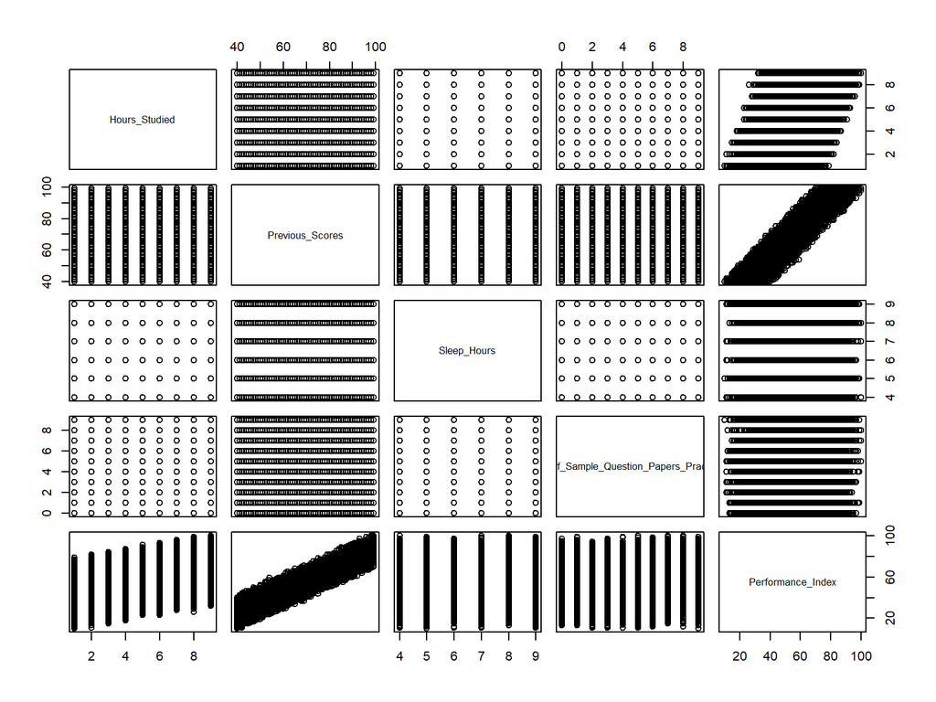

```r
Student_Performance_Data_numeric <- subset(student_performance_data, select = -Participation_in_Extracurricular_Activities)
pairs(Student_Performance_Data_numeric)
```

Detailed summary of numerical variables which also includes the number of missing values

```r
if (!requireNamespace("skimr", quietly = TRUE)) {
  install.packages("skimr")
}
library(skimr)
skim(student_performance_data)
```

Data summary

| Name | student_performance_data |
| --- | --- |
| Number of rows | 10000 |
| Number of columns | 6 |
| _______________________ |  |
| Column type frequency: |  |
| character | 1 |
| numeric | 5 |
| ________________________ |  |
| Group variables | None |

**Variable type: character**

| skim_variable | n_missing | complete_rate | min | max | empty | n_unique | whitespace |
| --- | --- | --- | --- | --- | --- | --- | --- |
| Participation_in_Extracurricular_Activities | 0 | 1 | 2 | 3 | 0 | 2 | 0 |

**Variable type: numeric**

| skim_variable | n_missing | complete_rate | mean | sd | p0 | p25 | p50 | p75 | p100 | hist |
| --- | --- | --- | --- | --- | --- | --- | --- | --- | --- | --- |
| Hours_Studied | 0 | 1 | 4.99 | 2.59 | 1 | 3 | 5 | 7 | 9 | ▇▇▃▇▇ |
| Previous_Scores | 0 | 1 | 69.45 | 17.34 | 40 | 54 | 69 | 85 | 99 | ▇▇▇▇▇ |
| Sleep_Hours | 0 | 1 | 6.53 | 1.70 | 4 | 5 | 7 | 8 | 9 | ▇▅▅▅▅ |
| No_Of_Sample_Question_Papers_Practiced | 0 | 1 | 4.58 | 2.87 | 0 | 2 | 5 | 7 | 9 | ▇▇▇▇▇ |
| Performance_Index | 0 | 1 | 55.22 | 19.21 | 10 | 40 | 55 | 71 | 100 | ▂▇▇▇▂ |

Calculating missing values of one variable:

```r
sum(is.na(student_performance_data$Participation_in_Extracurricular_Activities))
```

```
## [1] 0
```

There are no missing values in the dataset, so no need of handling missing values.

### Data Visualization:

Box plots for numerical columns:

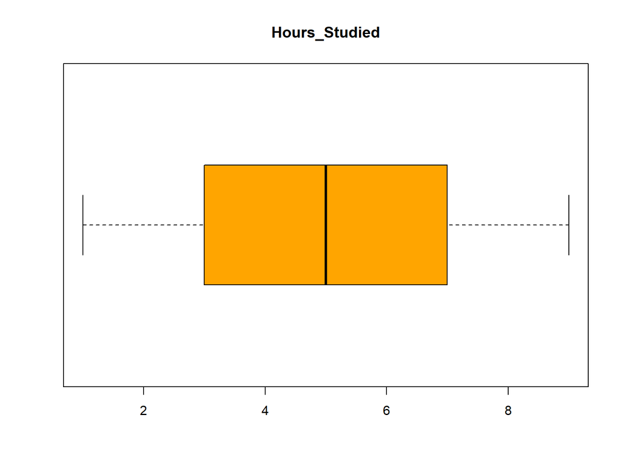

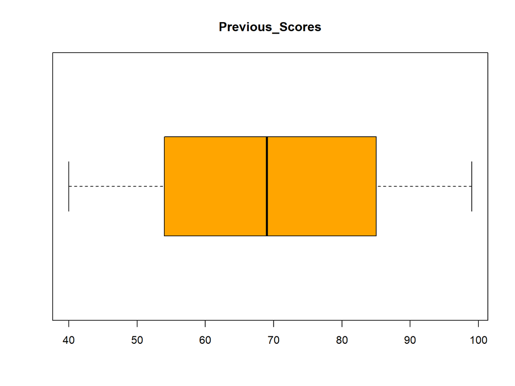

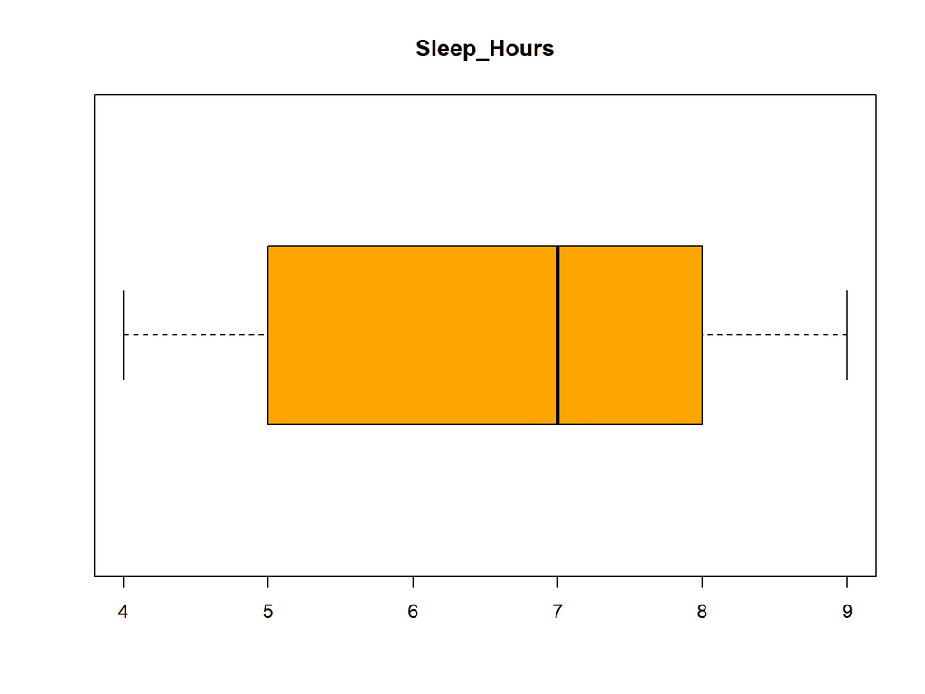

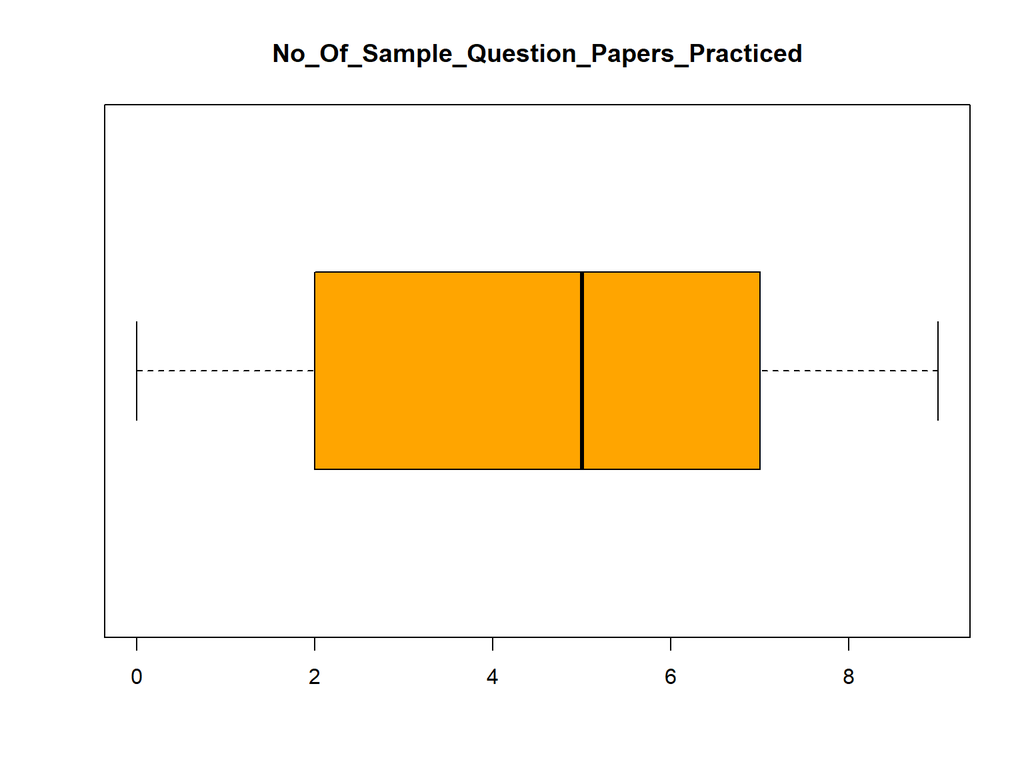

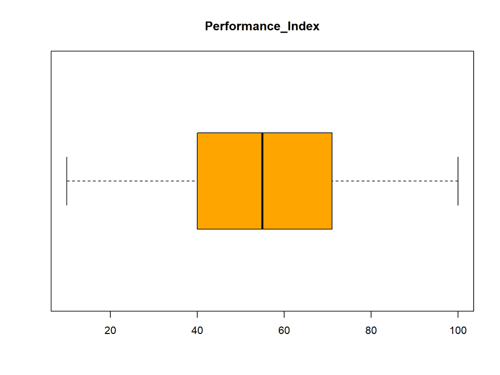

```r
library(ggplot2)
numerical_columns <- student_performance_data %>%
  select_if(is.numeric) %>% names()
for (var in numerical_columns) {
  boxplot(student_performance_data[[var]], main = var, col = "orange", border = "black", horizontal = TRUE)
}
```

Looking at the Box plots of numerical columns we can say that there are no outliers in the dataset.

Visualization of categorical variable : Participation_in_Extracurricular_Activities

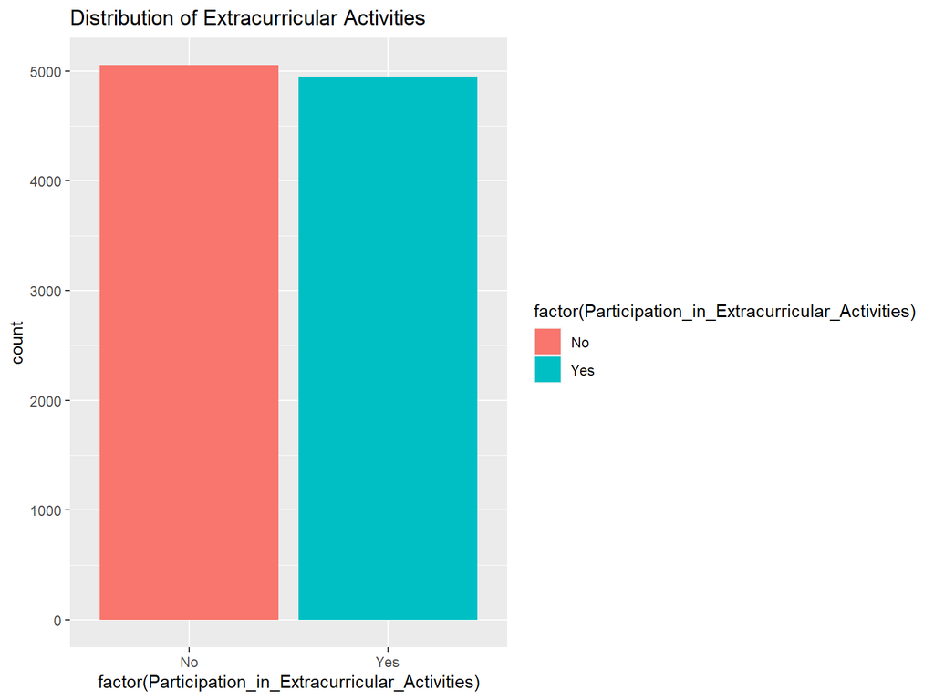

```r
ggplot(student_performance_data, aes(x = factor(Participation_in_Extracurricular_Activities), fill = factor(Participation_in_Extracurricular_Activities))) +
  geom_bar() +
  labs(title = "Distribution of Extracurricular Activities")
```

## Correlation matrix

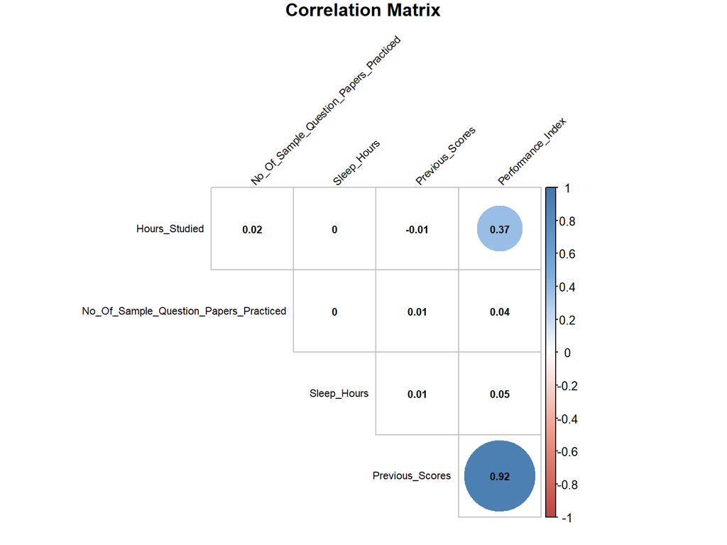

```r
if (!requireNamespace("corrplot", quietly = TRUE)) {
  install.packages("corrplot")
}
library(corrplot)
correlation_matrix <- cor(student_performance_data[numerical_columns])
color_palette <- colorRampPalette(c("#BB4444", "#EE9988", "#FFFFFF", "#77AADD", "#4477AA"))
corrplot(
  correlation_matrix,
  method = "circle",           # Use a circular layout
  type = "upper",              # Show upper part of the matrix
  order = "hclust",            # Order variables by hierarchical clustering
  tl.cex = 0.7,                # Text label size
  tl.col = "black",            # Text label color
  col = color_palette(200),       # Color palette
  addCoef.col = "black",       # Coefficient label color
  number.cex = 0.7,            # Coefficient label size
  diag = FALSE,                # Exclude diagonal elements
  mar = c(0, 0, 1, 0),          # Set margins (bottom margin for row names)
  title = "Correlation Matrix", # Add a title
  tl.srt = 45,                 # Rotate text labels
  addrect = 3                  # Highlight correlation coefficients with rectangles
)
```

## Visualization of highly correlated variables with performance index

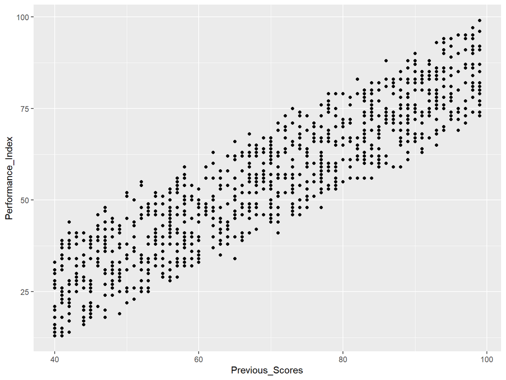

```r
set.seed(3008)
random_sample <- student_performance_data %>% sample_n(1000)
ggplot(random_sample, aes(x = Previous_Scores, y = Performance_Index)) +
 geom_point() +
labs( x = "Previous_Scores", y = "Performance_Index")
```

[figure not shown]

```r
set.seed(3008)
random_sample <- student_performance_data %>% sample_n(1000)
ggplot(student_performance_data, aes(x = Previous_Scores, y = Performance_Index, color = Participation_in_Extracurricular_Activities)) +
  geom_point() +
  labs(x = "Hours_Studied", y = "Performance_Index", color = "Participation_in_Extracurricular_Activities")
```

# Feature Selection

```r
#'Performance Index' is the column of interest for us
correlation_matrix <- cor(student_performance_data[numerical_columns])
performance_correlations <- correlation_matrix["Performance_Index", ]
print(sort(abs(performance_correlations),decreasing = TRUE))
```

```
##                      Performance_Index                        Previous_Scores
##                             1.00000000                             0.91518914
##                          Hours_Studied                            Sleep_Hours
##                             0.37373035                             0.04810584
## No_Of_Sample_Question_Papers_Practiced
##                             0.04326833
```

Converting the categorical column into numerical and finding out the correlation .

```r
library(dplyr)

# Convert 'Yes' to 1 and 'No' to 0
student_performance_data <- student_performance_data %>%
  mutate(Participation_in_Extracurricular_Activities = as.numeric(Participation_in_Extracurricular_Activities == 'Yes'))

print(student_performance_data$Participation_in_Extracurricular_Activities)
```

[output not shown]

[output cut: 263 more lines]

```r
correlation_matrix <- cor(student_performance_data)
performance_correlations <- correlation_matrix["Performance_Index", ]
print(sort(abs(performance_correlations),decreasing = TRUE))
```

```
##                           Performance_Index
##                                  1.00000000
##                             Previous_Scores
##                                  0.91518914
##                               Hours_Studied
##                                  0.37373035
##                                 Sleep_Hours
##                                  0.04810584
##      No_Of_Sample_Question_Papers_Practiced
##                                  0.04326833
## Participation_in_Extracurricular_Activities
##                                  0.02452495
```

Considering the top three highly correlated variables as my predictors for performance Index.

# Variables

Target variable : Performance_Index

Independent Variables : Previous_Scores, Hours_Studied, Sleep_Hours

# Model selection : Linear Regression

Before training the model , splitting the data into train and test data randomly

```r
set.seed(2901)
# shuffle the index for the testing data
test_indices<-sample(nrow(student_performance_data), 0.25*nrow(student_performance_data))
# Get the training data
trainingData<-student_performance_data[-test_indices,]
# Get the testing data
testingData<-student_performance_data[test_indices,]
```

```r
linear_model <- lm(Performance_Index ~ Previous_Scores + Hours_Studied + Sleep_Hours, data = trainingData)
summary(linear_model)
```

```
##
## Call:
## lm(formula = Performance_Index ~ Previous_Scores + Hours_Studied +
##     Sleep_Hours, data = trainingData)
##
## Residuals:
##     Min      1Q  Median      3Q     Max
## -8.2174 -1.4521  0.0272  1.4475  7.9966
##
## Coefficients:
##                   Estimate Std. Error t value Pr(>|t|)
## (Intercept)     -32.931532   0.147988 -222.53   <2e-16 ***
## Previous_Scores   1.020073   0.001430  713.10   <2e-16 ***
## Hours_Studied     2.855951   0.009519  300.01   <2e-16 ***
## Sleep_Hours       0.468166   0.014605   32.05   <2e-16 ***
## ---
## Signif. codes:  0 '***' 0.001 '**' 0.01 '*' 0.05 '.' 0.1 ' ' 1
##
## Residual standard error: 2.146 on 7496 degrees of freedom
## Multiple R-squared:  0.9876, Adjusted R-squared:  0.9876
## F-statistic: 1.984e+05 on 3 and 7496 DF,  p-value: < 2.2e-16
```

# Prediction

```r
predictions <- predict(linear_model, newdata = testingData)

# Calculating the accuracy of the model
MSE <- mean((testingData$Performance_Index - predictions)^2)
SSE <- sum((testingData$Performance_Index - predictions)^2)

# Accuracy of the model
cat("Mean Squared Error (MSE):", MSE, "\n")
```

```
## Mean Squared Error (MSE): 4.42762
```

```r
cat("Sum of Squared Errors (SSE):",SSE)
```

```
## Sum of Squared Errors (SSE): 11069.05
```

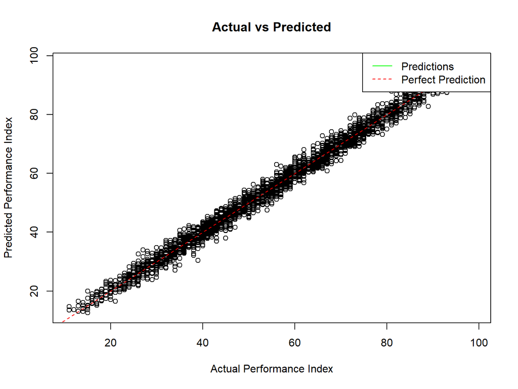

```r
# Plot the actual vs predicted values
plot(testingData$Performance_Index, predictions,
     main = "Actual vs Predicted",
     xlab = "Actual Performance Index",
     ylab = "Predicted Performance Index")

# Add a line indicating a perfect prediction (y = x)
abline(0, 1, col = "red", lty = 2)

# Add legend
legend("topright", legend = c("Predictions", "Perfect Prediction"),
       col = c("green", "red"), lty = c(1, 2))
```

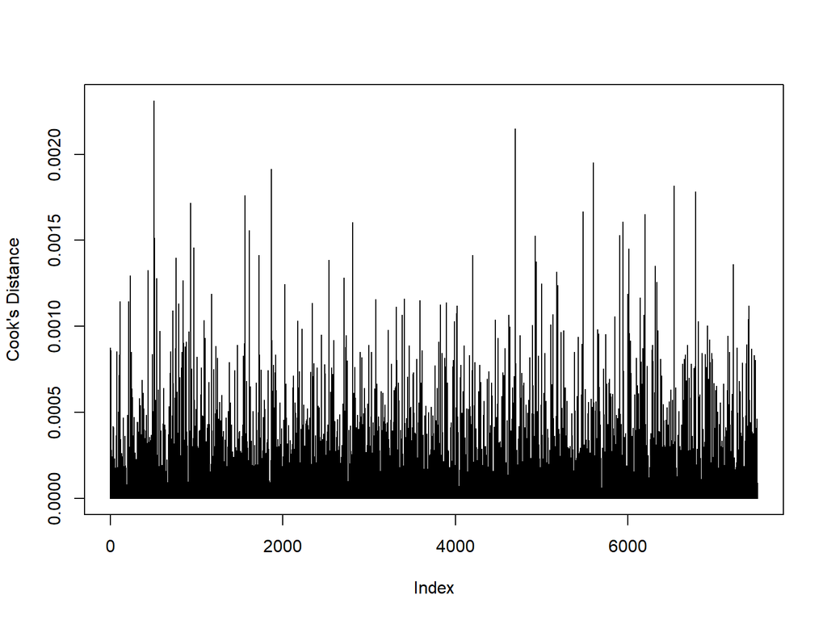

```r
cooks_distance<-cooks.distance(linear_model)
plot(cooks_distance,type="h", ylab="Cook's Distance" )
```

```r
as.numeric(names(cooks_distance)[cooks_distance>1])
```

```
## numeric(0)
```

Based on our defined threshold of 1, the output is an empty numeric vector (numeric(0)), indicating that there are no observations in our dataset with a high Cook’s Distance. Based on the threshold we selected, this result could be interpreted as meaning that your linear regression model is not significantly affected by any extreme outliers or influential points.

# Assumption Validation

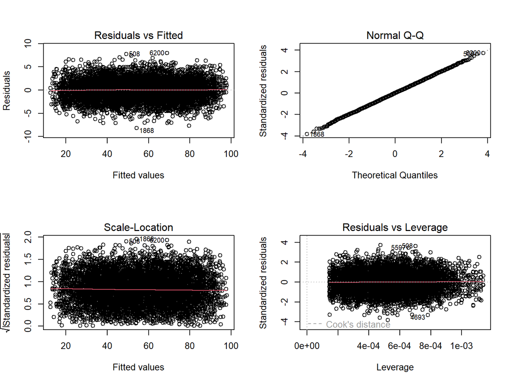

```r
par(mfrow=c(2,2))
plot(linear_model)
```

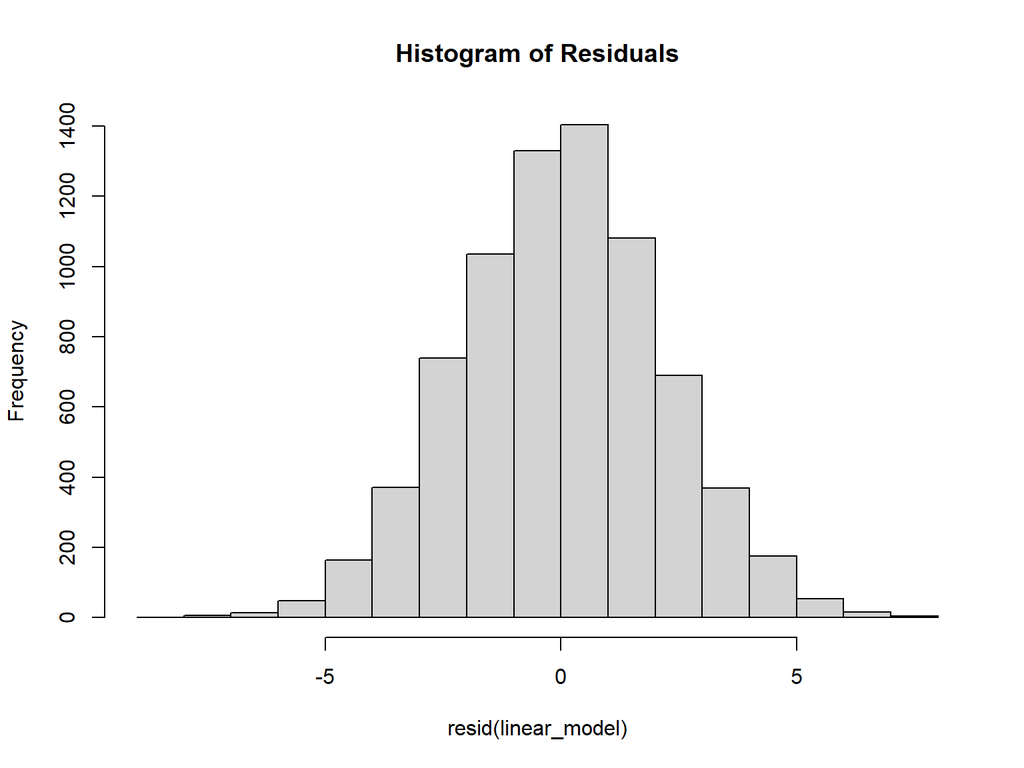

```r
par(mfrow=c(1,1))
hist(resid(linear_model),main="Histogram of Residuals")
```

# Results and conclusion

The linear regression model is given by : Performance_Index = -32.93 + 1.02 * Previous_Scores + 2.85 * Hours_Studied + 0.47 * Sleep_Hours

The Performance_Index appears to be well-predicted by the linear regression model using the provided predictors (Previous_Scores, Hours_Studied, Sleep_Hours).

The model has a low prediction error (low MSE) and a high explanatory power (high R square).

With an R-Square value of 0.9876, the dependent variable’s variance is roughly 98.76% explained by the model. This points to a very high goodness of fit.

The signs of the predictors’ coefficients make sense, and they are statistically significant.

The average squared difference between the expected and actual values is 4.43, which is represented by the Mean Squared Error (MSE). Greater predictive accuracy is indicated by lower MSE values.

# References

Used ChatGPT for plotting correlation matrix and actual vs predicted data Used Professor Yixun Xing Rmd file for assumptions and splitting data